# Create consensus hotspot maf

Krutika Gaonkar for D3b

In the previous step we gather all known cancer hotspots by scavenging calls by - checking for overlap with amino acid positions in a curated and published cancer hotspot [database](https://www.cancerhotspots.org/files/hotspots_v2.xls) - checking for overlap with non-coding region hotspots mutations , here we are using the in TERT promoter region

## Setup

```r
library("tidyverse")
library("maftools")

root_dir <- rprojroot::find_root(rprojroot::has_dir(".git"))
data_dir <- file.path(root_dir, "data")

results_dir <- file.path(root_dir,
                         "analyses",
                         "hotspots-detection",
                         "results")
# Make output folder
if (!dir.exists(results_dir )) {
  dir.create(results_dir , recursive = TRUE)
}

scratch_dir <- file.path(
  root_dir,
  "scratch",
  "hotspot-detection"
)

# Import function to split MNV to SNV
source(file.path(root_dir, "analyses", "snv-callers", "util", "split_mnv.R"))

maf_coltypes <- readRDS(file.path("input", "maf_coltypes.RDS"))
# maf_coltypes is a named vector with column types information for each column in a maf file
# More description about maf format is available
# [here](https://docs.gdc.cancer.gov/Data/File_Formats/MAF_Format/)

# combined hotspot calls
combined_maf_hotspots_filt <- list.files(path = scratch_dir,pattern = ".RDS",full.names = TRUE) %>%
  map_dfr(readRDS)

# MNVs are split into SNVs
combined_maf_hotspots_filt_mnv_split <- split_mnv(combined_maf_hotspots_filt) %>%
  # removing mvv_id and mnv_pos column
  # since they uniquely numbered per caller variant calls
  # in the merged combined_maf_hotspots_filt
  select(-mnv_id, -mnv_pos)

combined_maf_hotspots_filt <- combined_maf_hotspots_filt %>%
  # removing MNVs here
  filter(!Variant_Type %in% c("DNP", "TNP", "ONP")) %>%
  # adding the MNV split SNV alleles here
  union_all(combined_maf_hotspots_filt_mnv_split)

# hotspot mutation maf file output
output_file <- file.path(results_dir,"pbta-snv-scavenged-hotspots.maf.tsv.gz")
```

## Gather consensus maf file for hotspots

The main tasks are: - gather read supports for REF and ALT from multiple callers adding values from any 1 caller in the order strelka2 > mutect2 > lancet > vardict

### Filter hotspots not found in consensus calls

```r
# These columns provide unique values
# to check for exact in the 2 dataframes
join_cols <- c("Hugo_Symbol",
               "Entrez_Gene_Id",
               "NCBI_Build",
               "Chromosome",
               "Start_Position",
               "End_Position",
               "Strand",
               "Variant_Classification",
               "Variant_Type",
               "Reference_Allele",
               "Tumor_Seq_Allele1",
               "Tumor_Seq_Allele2",
               "Tumor_Sample_Barcode")


caller_counts <- combined_maf_hotspots_filt %>%
  select(join_cols,caller) %>%
  unique() %>%
  group_by_at(join_cols) %>%
  summarise(caller_count = n(),
            caller = paste(unique(caller), collapse=';')) %>%
  ungroup()
```

### Gather count and qual values

For the following columns which are unique to each caller:

```
unique_cols <- c("t_depth",
                 "n_depth",
                 "t_ref_count",
                 "n_ref_count",
                 "t_alt_count",
                 "n_alt_count",
                 "vcf_qual",
                 "caller")
```

We will prefer the call from strelka, then mutect2, then lancet and then last vardict at this step.

```r
# These columns are unique to each caller maf file.
# Read support and quality are intrinsic values gathered
# from the tools calling the variant so can vary in values.
unique_cols <- c("t_depth",
                 "n_depth",
                 "t_ref_count",
                 "n_ref_count",
                 "t_alt_count",
                 "n_alt_count",
                 "vcf_qual",
                 "caller")

# We will create a union of calls where each caller specific
# values in the unique columns described above are renamed
# with a tag specifying caller name
combined_maf_hotspots_filt <- filter(combined_maf_hotspots_filt,caller=="strelka2") %>%
  rename_at(vars(unique_cols), ~str_c("strelka2_", .)) %>%

  # join mutect2 calls
  full_join(
    filter(combined_maf_hotspots_filt,caller=="mutect2"),
    by=setdiff(names(combined_maf_hotspots_filt ), unique_cols)) %>%
  # rename *_count columns to mutect2_*count
  rename_at(vars(unique_cols), ~str_c("mutect2_", .)) %>%

  # join lancet calls
  full_join(
    filter( combined_maf_hotspots_filt,caller=="lancet"),
    by=setdiff(names(combined_maf_hotspots_filt ), unique_cols)) %>%
  # rename *_count columns to lancet_*count
  rename_at(vars(unique_cols), ~str_c("lancet_", .)) %>%

  # join vardict
  full_join(
    filter(combined_maf_hotspots_filt,caller=="vardict"),
    by=setdiff(names(combined_maf_hotspots_filt ), unique_cols)) %>%
  # rename *_count columns to vardict_*count
  rename_at(vars(unique_cols), ~str_c("vardict_", .))


# We will select unique cols for each variant call in the order
# strelka2 > mutect2 > lancet > vardict
combined_maf_hotspots_filt <- combined_maf_hotspots_filt %>%
  # Given a set of vectors, coalesce() finds the first non-missing value at each position.
  mutate( "t_depth" = coalesce(strelka2_t_depth,mutect2_t_depth,lancet_t_depth,vardict_t_depth),
          "n_depth" = coalesce(strelka2_n_depth,mutect2_n_depth,lancet_n_depth,vardict_n_depth),
          "t_ref_count" = coalesce(strelka2_t_ref_count,mutect2_t_ref_count,lancet_t_ref_count,vardict_t_ref_count),
          "n_ref_count" = coalesce(strelka2_n_ref_count,mutect2_n_ref_count,lancet_n_ref_count,vardict_n_ref_count),
          "t_alt_count" = coalesce(strelka2_t_alt_count,mutect2_t_alt_count,lancet_t_alt_count,vardict_t_alt_count),
          "n_alt_count" = coalesce(strelka2_n_alt_count,mutect2_n_alt_count,lancet_n_alt_count,vardict_n_alt_count),
          "vcf_qual" = coalesce(strelka2_vcf_qual,mutect2_vcf_qual,lancet_vcf_qual,vardict_vcf_qual),
          # calculate VAF
          VAF = t_alt_count/(t_alt_count+t_ref_count))%>%
  # Filter with vaf_filter parm in this notebook
  dplyr::filter(VAF >= params$vaf_filter)
```

## Identify read support for variant type per caller

We will try to identify the read support for each variant type from each callers to visualize if any callers call hostspot sites in specific variant types with low read support calls

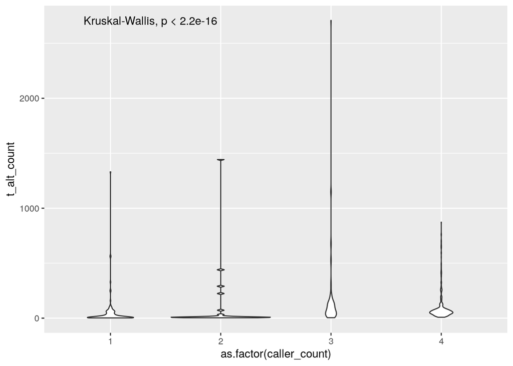

```r
## adding in caller info to plot caller information

combined_maf_hotspots_filt <- combined_maf_hotspots_filt %>%
  left_join(caller_counts,by=join_cols)

ggplot(combined_maf_hotspots_filt[,c("caller","caller_count","t_alt_count")],
       aes(x=as.factor(caller_count),y=t_alt_count))+
  geom_violin()+
  ggpubr::stat_compare_means()
```

Hotspot sites called by just 1 caller seem to have majority low read support and a few are found in 3 caller ( now captured in 3 callers because of the variant being present in vardict)

## Identify calls unique to a caller

Lets look at these calls that are unique to 1 caller.

```r
combined_maf_hotspots_filt %>%
  filter(caller_count==1)
```

| Hugo_Symbol | Entrez_Gene_Id | Center | NCBI_Build | Chromosome | Start_Position | End_Position | Strand | Variant_Classification | Variant_Type | Reference_Allele | Tumor_Seq_Allele1 | Tumor_Seq_Allele2 | dbSNP_RS | dbSNP_Val_Status | Tumor_Sample_Barcode | Matched_Norm_Sample_Barcode | Match_Norm_Seq_Allele1 | Match_Norm_Seq_Allele2 | Tumor_Sample_UUID | Matched_Norm_Sample_UUID | HGVSc | HGVSp | HGVSp_Short | Transcript_ID | Exon_Number | strelka2_t_depth | strelka2_t_ref_count | strelka2_t_alt_count | strelka2_n_depth | … |
| --- | --- | --- | --- | --- | --- | --- | --- | --- | --- | --- | --- | --- | --- | --- | --- | --- | --- | --- | --- | --- | --- | --- | --- | --- | --- | --- | --- | --- | --- | --- |
| NOTCH1 | 4851 | . | GRCh38 | chr9 | 136517781 | 136517781 | + | Missense_Mutation | SNP | A | A | C | NA | NA | BS_F0GNWEJJ | BS_F5EX3ZY5 | A | A | NA | NA | c.1412T>G | p.Ile471Ser | p.I471S | ENST00000277541 | 8/34 | 143 | 116 | 27 | 67 | … |
| KRAS | 3845 | . | GRCh38 | chr12 | 25227343 | 25227343 | + | Missense_Mutation | SNP | G | G | T | rs121913238 | NA | BS_89RCN9PF | BS_5GRVA3YE | G | G | NA | NA | c.181C>A | p.Gln61Lys | p.Q61K | ENST00000256078 | 3/6 | 230 | 216 | 14 | 110 | … |
| KRAS | 3845 | . | GRCh38 | chr12 | 25227343 | 25227343 | + | Missense_Mutation | SNP | G | G | T | rs121913238 | NA | BS_3Y44RJXS | BS_K44TMQ9G | G | G | NA | NA | c.181C>A | p.Gln61Lys | p.Q61K | ENST00000256078 | 3/6 | 134 | 96 | 38 | 80 | … |
| KRAS | 3845 | . | GRCh38 | chr12 | 25245348 | 25245348 | + | Missense_Mutation | SNP | C | C | G | rs121913535 | NA | BS_RGSJMSRE | BS_ZNB7T5SZ | C | C | NA | NA | c.37G>C | p.Gly13Arg | p.G13R | ENST00000256078 | 2/6 | 183 | 80 | 103 | 56 | … |
| FBXW7 | 55294 | . | GRCh38 | chr4 | 152347073 | 152347073 | + | Splice_Site | SNP | T | T | A | rs1319900991 | NA | BS_XBBBE8V2 | BS_TKRHXGZQ | T | T | NA | NA | c.585-2A>T | NA | p.X195_splice | ENST00000603548 | NA | 145 | 126 | 19 | 41 | … |
| TP53 | 7157 | . | GRCh38 | chr17 | 7675095 | 7675095 | + | Missense_Mutation | SNP | C | C | A | NA | NA | BS_JB3J82ZK | BS_WMVYQREN | C | C | NA | NA | c.517G>T | p.Val173Leu | p.V173L | ENST00000269305 | 5/11 | 130 | 12 | 118 | 71 | … |
| BRAF | 673 | . | GRCh38 | chr7 | 140753336 | 140753336 | + | Missense_Mutation | SNP | A | A | T | rs113488022 | NA | BS_NHRNZRQV | BS_88B4WV6J | A | A | NA | NA | c.1799T>A | p.Val600Glu | p.V600E | ENST00000646891 | 15/18 | 143 | 105 | 38 | 71 | … |
| KRAS | 3845 | . | GRCh38 | chr12 | 25227343 | 25227343 | + | Missense_Mutation | SNP | G | G | T | rs121913238 | NA | BS_9HEMB7RK | BS_K44TMQ9G | G | G | NA | NA | c.181C>A | p.Gln61Lys | p.Q61K | ENST00000256078 | 3/6 | 102 | 76 | 26 | 80 | … |
| BRAF | 673 | . | GRCh38 | chr7 | 140753354 | 140753354 | + | Missense_Mutation | SNP | T | T | C | rs121913338 | NA | BS_52ETE050 | BS_RNNWQNGX | T | T | NA | NA | c.1781A>G | p.Asp594Gly | p.D594G | ENST00000646891 | 15/18 | 521 | 507 | 14 | 209 | … |
| CTNNB1 | 1499 | . | GRCh38 | chr3 | 41224606 | 41224606 | + | Missense_Mutation | SNP | G | G | T | rs28931588 | NA | BS_XDY9BYRK | BS_0C83MQ6C | G | G | NA | NA | c.94G>T | p.Asp32Tyr | p.D32Y | ENST00000645320 | 3/15 | NA | NA | NA | NA | … |

[output cut: 138 more lines]

```r
# gather distribution of callers in the unique_1caller_hotspots
unique_1caller_hotspots <- combined_maf_hotspots_filt %>%
  filter(caller_count==1) %>%
  group_by(caller) %>%
  tally()

unique_1caller_hotspots
```

| caller | n |
| --- | --- |
| lancet | 38 |
| mutect2 | 24 |
| strelka2 | 9 |
| vardict | 77 |

Vardict calls a lot of variants summarized [here](https://github.com/AlexsLemonade/OpenPBTA-analysis/blob/master/analyses/snv-callers/README.md) In snv-callers consensus calling method we didn’t consider vardict calls so we will need to filter out vardict only calls from the hotspots to be consistent

```r
 combined_maf_hotspots_filt <- combined_maf_hotspots_filt %>% filter(caller !="vardict")
```

## Save hotspots

```r
combined_maf_hotspots_filt %>%
  # remove caller unique columns
  select(-starts_with("strelka2_"),-starts_with("mutect2_"),-starts_with("lancet_"),-starts_with("vardict_")) %>%
  as.data.frame() %>%
  # Write to a TSV file, change NAs back to "."
  readr::write_tsv(output_file, na = ".")
```